# discussion_presentation_data_exploration

Chase Brewster

1/23/2020

## Step 1

This .Rmd holds every combination of expirements we have ran. It has all assessment intervals (0, 20, 15, 10, 5, every year), tested against all errors (.5, .3, .1), and all harvest control rules (.95 - .50), under the constant fmsy scenario.

The resulting dataset - “alldata” - can then be altered independently to create different data explorations and visualizations.

To explore data, follow the steps below:

1. Packages Needed

```r
library(tidyverse)
library(here)
```

## Step 2

2. Read in the csv files, add columns for data exploration grouping, and bind all csv’s to the main data set, “alldata”

```r
low_err <- read_csv(file=file.path(here(),"/Presentation/discussion/decisiontable_lowerr.csv"))
mid_err <- read_csv(file=file.path(here(),"/Presentation/discussion/decisiontable_miderr.csv"))
high_err <- read_csv(file=file.path(here(),"/Presentation/discussion/decisiontable_higherr.csv"))

low_err_10 <- read_csv(file=file.path(here(),"/Presentation/discussion/decisiontable_lowerr_10.csv"))
mid_err_10 <- read_csv(file=file.path(here(),"/Presentation/discussion/decisiontable_miderr_10.csv"))
high_err_10 <- read_csv(file=file.path(here(),"/Presentation/discussion/decisiontable_higherr_10.csv"))

low_err_15 <- read_csv(file=file.path(here(),"/Presentation/discussion/decisiontable_lowerr_15.csv"))
mid_err_15 <- read_csv(file=file.path(here(),"/Presentation/discussion/decisiontable_miderr_15.csv"))
high_err_15 <- read_csv(file=file.path(here(),"/Presentation/discussion/decisiontable_higherr_15.csv"))

low_err_20 <- read_csv(file=file.path(here(),"/Presentation/discussion/decisiontable_lowerr_20.csv"))
mid_err_20 <- read_csv(file=file.path(here(),"/Presentation/discussion/decisiontable_miderr_20.csv"))
high_err_20 <- read_csv(file=file.path(here(),"/Presentation/discussion/decisiontable_higherr_20.csv"))

low_err_0 <- read_csv(file=file.path(here(),"/Presentation/discussion/decisiontable_lowerr_0.csv"))
mid_err_0 <- read_csv(file=file.path(here(),"/Presentation/discussion/decisiontable_miderr_0.csv"))
high_err_0 <- read_csv(file=file.path(here(),"/Presentation/discussion/decisiontable_higherr_0.csv"))

low_err_all <- read_csv(file=file.path(here(),"/Presentation/discussion/decisiontable_lowerr_all.csv"))
mid_err_all <- read_csv(file=file.path(here(),"/Presentation/discussion/decisiontable_miderr_all.csv"))
high_err_all <- read_csv(file=file.path(here(),"/Presentation/discussion/decisiontable_higherr_all.csv"))

low_err_1 <- low_err %>%
  filter(year == 100) %>%
  mutate(status = ifelse(f_ratio == 0, "closed", ifelse(b <= 1000, "over", "good"))) %>%
  mutate(growth = ifelse(r_0 <= .3, "slow", ifelse(r_0 > .3 & r_0 <= .5, "medium", "fast"))) %>%
  mutate(assess = "5")

mid_err_1 <- mid_err %>%
  filter(year == 100) %>%
  mutate(status = ifelse(f_ratio == 0, "closed", ifelse(b <= 1000, "over", "good"))) %>%
  mutate(growth = ifelse(r_0 <= .3, "slow", ifelse(r_0 > .3 & r_0 <= .5, "medium", "fast"))) %>%
  mutate(assess = "5")

high_err_1 <- high_err %>%
  filter(year == 100) %>%
  mutate(status = ifelse(f_ratio == 0, "closed", ifelse(b <= 1000, "over", "good"))) %>%
  mutate(growth = ifelse(r_0 <= .3, "slow", ifelse(r_0 > .3 & r_0 <= .5, "medium", "fast"))) %>%
  mutate(assess = "5")

low_err_2 <- low_err_10 %>%
  filter(year == 100) %>%
  mutate(status = ifelse(f_ratio == 0, "closed", ifelse(b <= 1000, "over", "good"))) %>%
  mutate(growth = ifelse(r_0 <= .3, "slow", ifelse(r_0 > .3 & r_0 <= .5, "medium", "fast"))) %>%
  mutate(assess = "10")

mid_err_2 <- mid_err_10 %>%
  filter(year == 100) %>%
  mutate(status = ifelse(f_ratio == 0, "closed", ifelse(b <= 1000, "over", "good"))) %>%
  mutate(growth = ifelse(r_0 <= .3, "slow", ifelse(r_0 > .3 & r_0 <= .5, "medium", "fast"))) %>%
  mutate(assess = "10")

high_err_2 <- high_err_10 %>%
  filter(year == 100) %>%
  mutate(status = ifelse(f_ratio == 0, "closed", ifelse(b <= 1000, "over", "good"))) %>%
  mutate(growth = ifelse(r_0 <= .3, "slow", ifelse(r_0 > .3 & r_0 <= .5, "medium", "fast"))) %>%
  mutate(assess = "10")

low_err_3 <- low_err_15 %>%
  filter(year == 100) %>%
  mutate(status = ifelse(f_ratio == 0, "closed", ifelse(b <= 1000, "over", "good"))) %>%
  mutate(growth = ifelse(r_0 <= .3, "slow", ifelse(r_0 > .3 & r_0 <= .5, "medium", "fast"))) %>%
  mutate(assess = "15")

mid_err_3 <- mid_err_15 %>%
  filter(year == 100) %>%
  mutate(status = ifelse(f_ratio == 0, "closed", ifelse(b <= 1000, "over", "good"))) %>%
  mutate(growth = ifelse(r_0 <= .3, "slow", ifelse(r_0 > .3 & r_0 <= .5, "medium", "fast"))) %>%
  mutate(assess = "15")

high_err_3 <- high_err_15 %>%
  filter(year == 100) %>%
  mutate(status = ifelse(f_ratio == 0, "closed", ifelse(b <= 1000, "over", "good"))) %>%
  mutate(growth = ifelse(r_0 <= .3, "slow", ifelse(r_0 > .3 & r_0 <= .5, "medium", "fast"))) %>%
  mutate(assess = "15")

low_err_4 <- low_err_20 %>%
  filter(year == 100) %>%
  mutate(status = ifelse(f_ratio == 0, "closed", ifelse(b <= 1000, "over", "good"))) %>%
  mutate(growth = ifelse(r_0 <= .3, "slow", ifelse(r_0 > .3 & r_0 <= .5, "medium", "fast"))) %>%
  mutate(assess = "20")

mid_err_4 <- mid_err_20 %>%
  filter(year == 100) %>%
  mutate(status = ifelse(f_ratio == 0, "closed", ifelse(b <= 1000, "over", "good"))) %>%
  mutate(growth = ifelse(r_0 <= .3, "slow", ifelse(r_0 > .3 & r_0 <= .5, "medium", "fast"))) %>%
  mutate(assess = "20")

high_err_4 <- high_err_20 %>%
  filter(year == 100) %>%
  mutate(status = ifelse(f_ratio == 0, "closed", ifelse(b <= 1000, "over", "good"))) %>%
  mutate(growth = ifelse(r_0 <= .3, "slow", ifelse(r_0 > .3 & r_0 <= .5, "medium", "fast"))) %>%
  mutate(assess = "20")

low_err_5 <- low_err_0 %>%
  filter(year == 100) %>%
  mutate(status = ifelse(f_ratio == 0, "closed", ifelse(b <= 1000, "over", "good"))) %>%
  mutate(growth = ifelse(r_0 <= .3, "slow", ifelse(r_0 > .3 & r_0 <= .5, "medium", "fast"))) %>%
  mutate(assess = "0")

mid_err_5 <- mid_err_0 %>%
  filter(year == 100) %>%
  mutate(status = ifelse(f_ratio == 0, "closed", ifelse(b <= 1000, "over", "good"))) %>%
  mutate(growth = ifelse(r_0 <= .3, "slow", ifelse(r_0 > .3 & r_0 <= .5, "medium", "fast"))) %>%
  mutate(assess = "0")

high_err_5 <- high_err_0 %>%
  filter(year == 100) %>%
  mutate(status = ifelse(f_ratio == 0, "closed", ifelse(b <= 1000, "over", "good"))) %>%
  mutate(growth = ifelse(r_0 <= .3, "slow", ifelse(r_0 > .3 & r_0 <= .5, "medium", "fast"))) %>%
  mutate(assess = "0")

low_err_6 <- low_err_all %>%
  filter(year == 100) %>%
  mutate(status = ifelse(f_ratio == 0, "closed", ifelse(b <= 1000, "over", "good"))) %>%
  mutate(growth = ifelse(r_0 <= .3, "slow", ifelse(r_0 > .3 & r_0 <= .5, "medium", "fast"))) %>%
  mutate(assess = "all")

mid_err_6 <- mid_err_all %>%
  filter(year == 100) %>%
  mutate(status = ifelse(f_ratio == 0, "closed", ifelse(b <= 1000, "over", "good"))) %>%
  mutate(growth = ifelse(r_0 <= .3, "slow", ifelse(r_0 > .3 & r_0 <= .5, "medium", "fast"))) %>%
  mutate(assess = "all")

high_err_6 <- high_err_all %>%
  filter(year == 100) %>%
  mutate(status = ifelse(f_ratio == 0, "closed", ifelse(b <= 1000, "over", "good"))) %>%
  mutate(growth = ifelse(r_0 <= .3, "slow", ifelse(r_0 > .3 & r_0 <= .5, "medium", "fast"))) %>%
  mutate(assess = "all")


alldata <- rbind(low_err_1, mid_err_1, high_err_1, low_err_2, mid_err_2, high_err_2, low_err_3, mid_err_3, high_err_3, low_err_4, mid_err_4, high_err_4, low_err_5, mid_err_5, high_err_5, low_err_6, mid_err_6, high_err_6)

#Write as CSV:
#write.csv(alldata, file=file.path(here(),"/Presentation/discussion/alldata.csv"),
#           row.names = FALSE)
```

3. From here, use the “alldata” dataset to explore different combinations. Always create a new dataframe for the specific exploration when using “alldata” to avoid writing over the main dataset.

We will have to recategorize some variables as factors to properly group and graph.

```r
alldata <- read_csv("alldata.csv")

#Change the NA to "all"
alldata[is.na(alldata)] <- "all" #turn NAs to all
```

## Assessment + Error

Assessment Intervals & Error

Graphs:

Moderate climate change - facet wrap by growth rates:

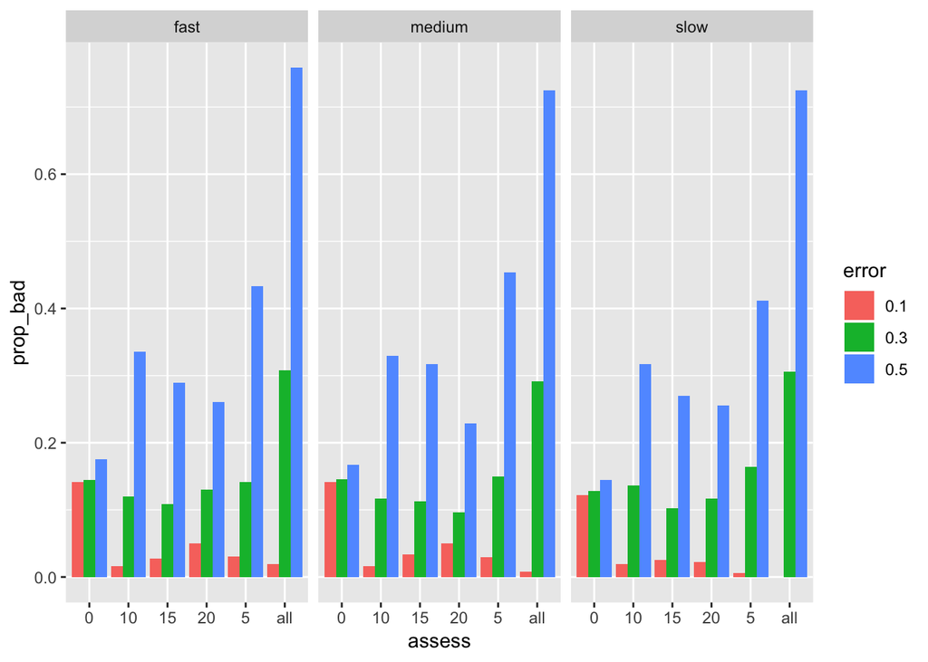

Severe climate change - facet wrap by growth rates:

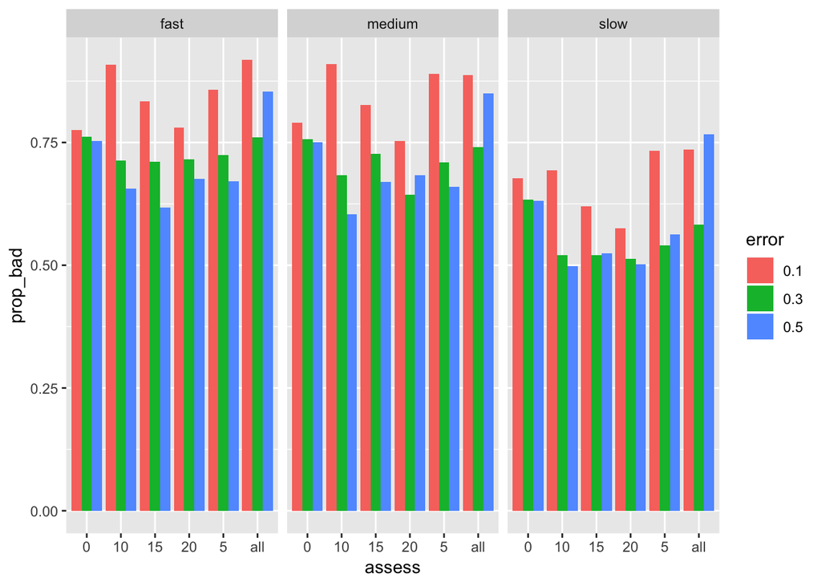

Moderate climate change - facet wrap by initial biomass:

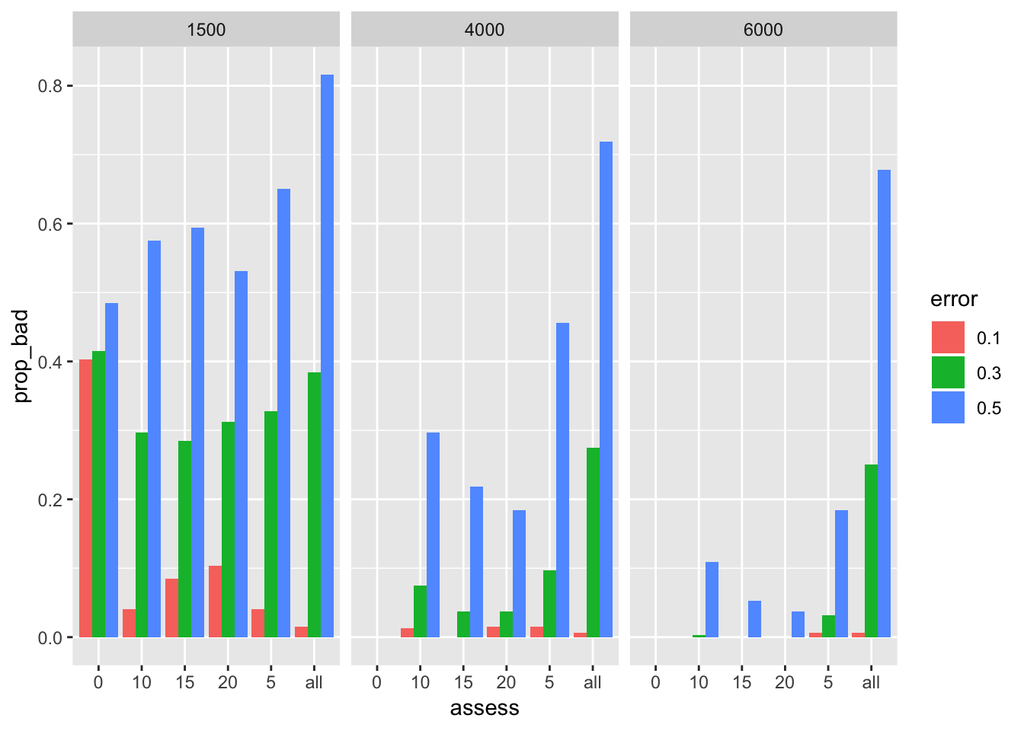

Severe climate change - facet wrap by initial biomass:

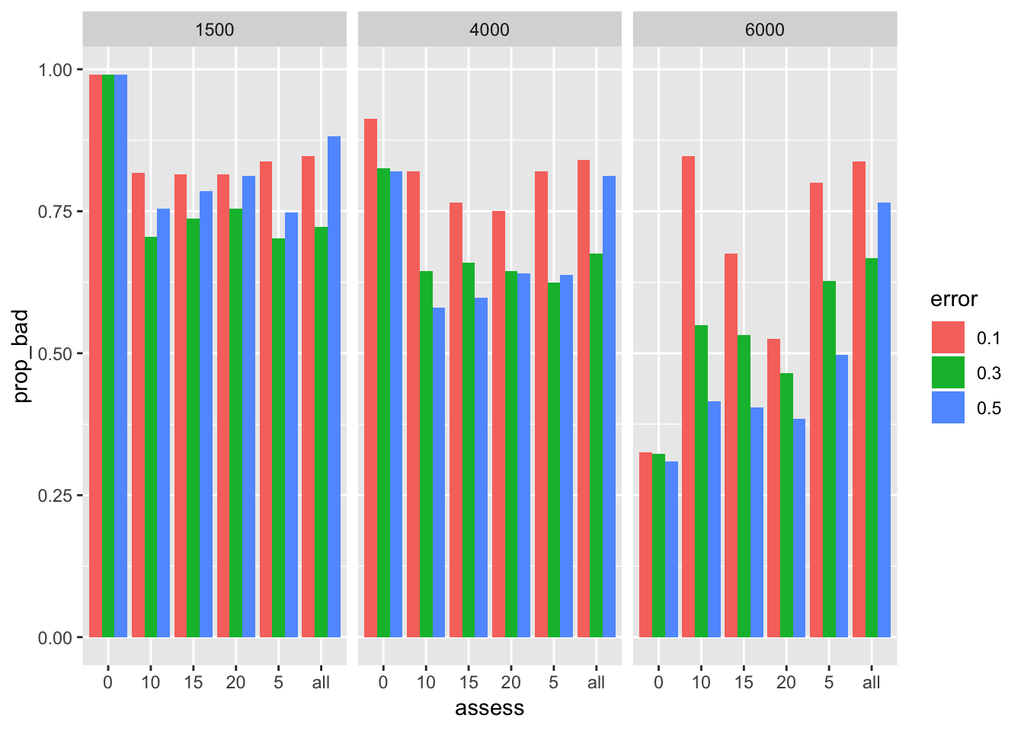

Moderate climate change - facet wrap by HCR

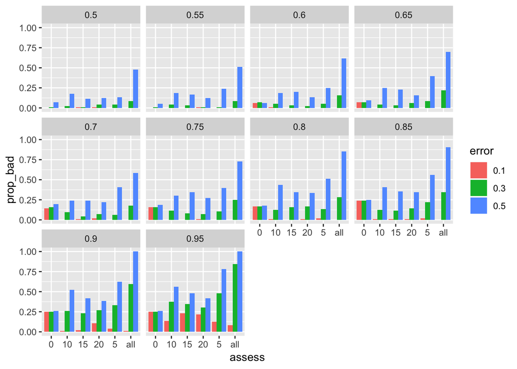

Severe climate change - facet wrap by HCR

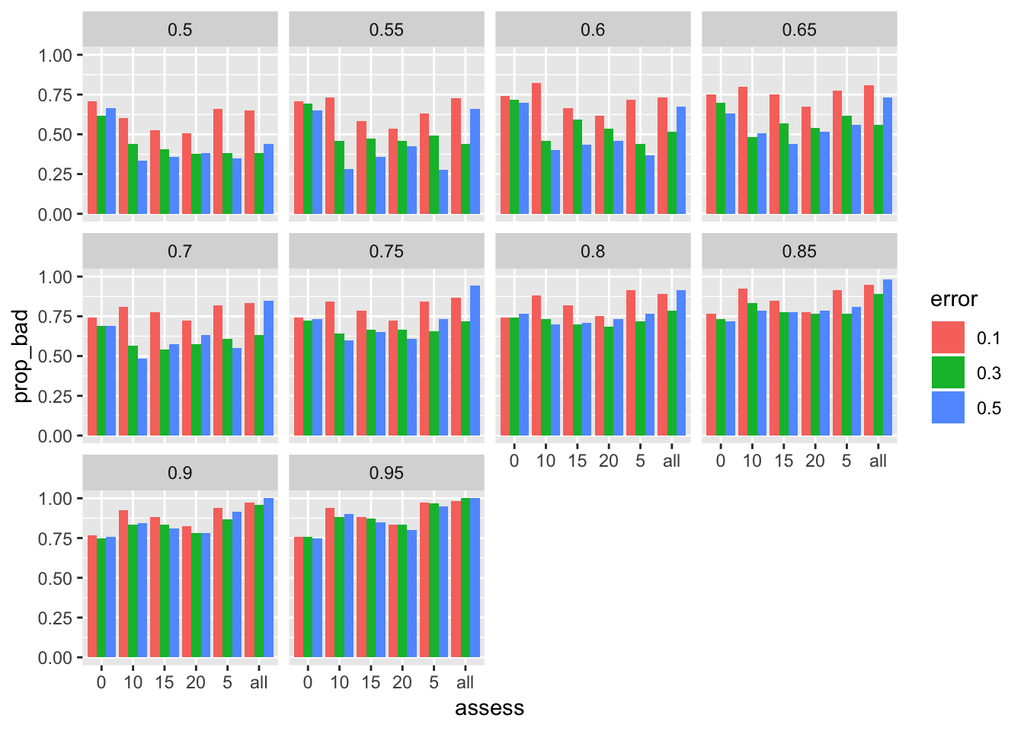

## Error + HCRs

Error & Harvest Control Rules

Graphs:  
Moderate climate change - facet wrap by growth rates:

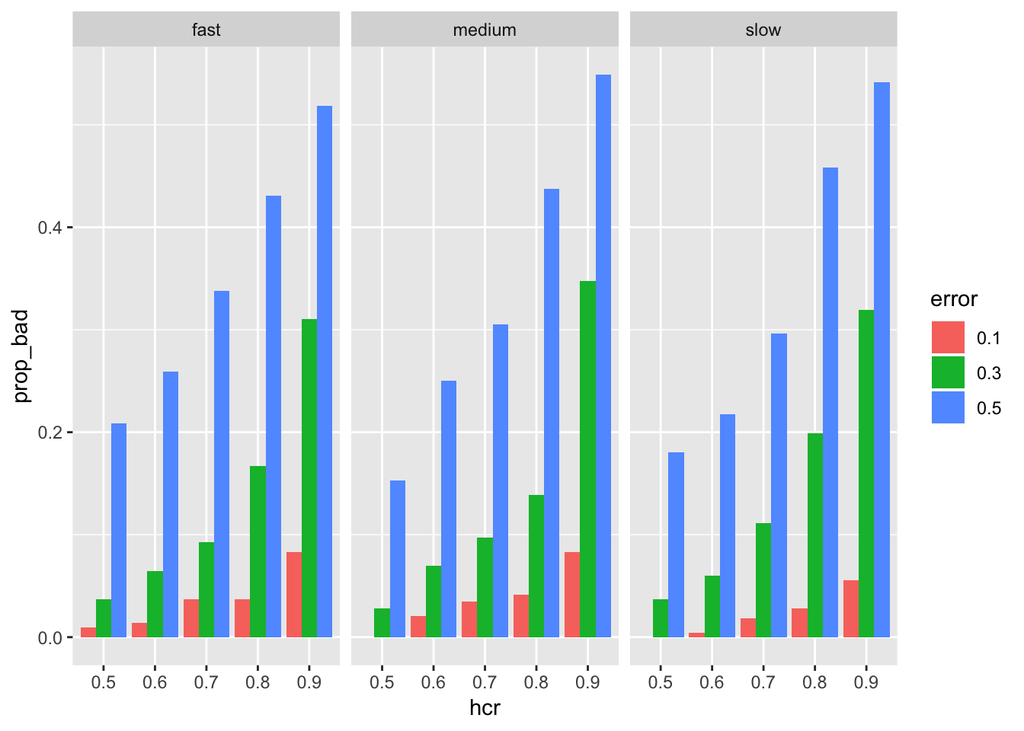

Severe climate change - facet wrap by growth rates:

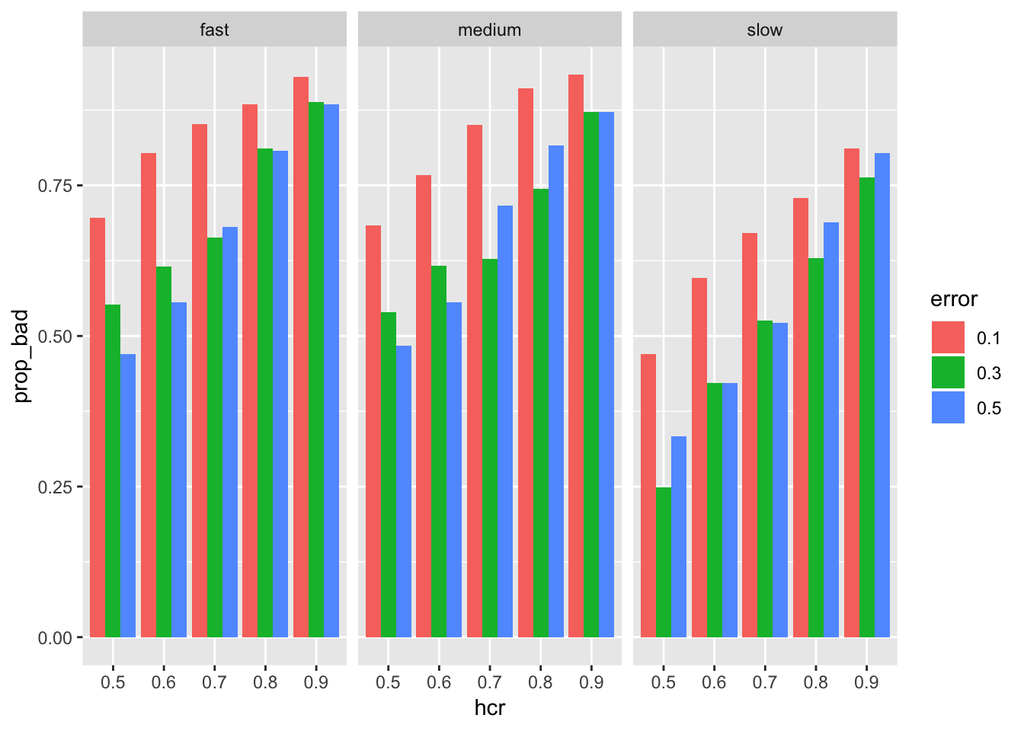

Moderate climate change - facet wrap by initial biomass:

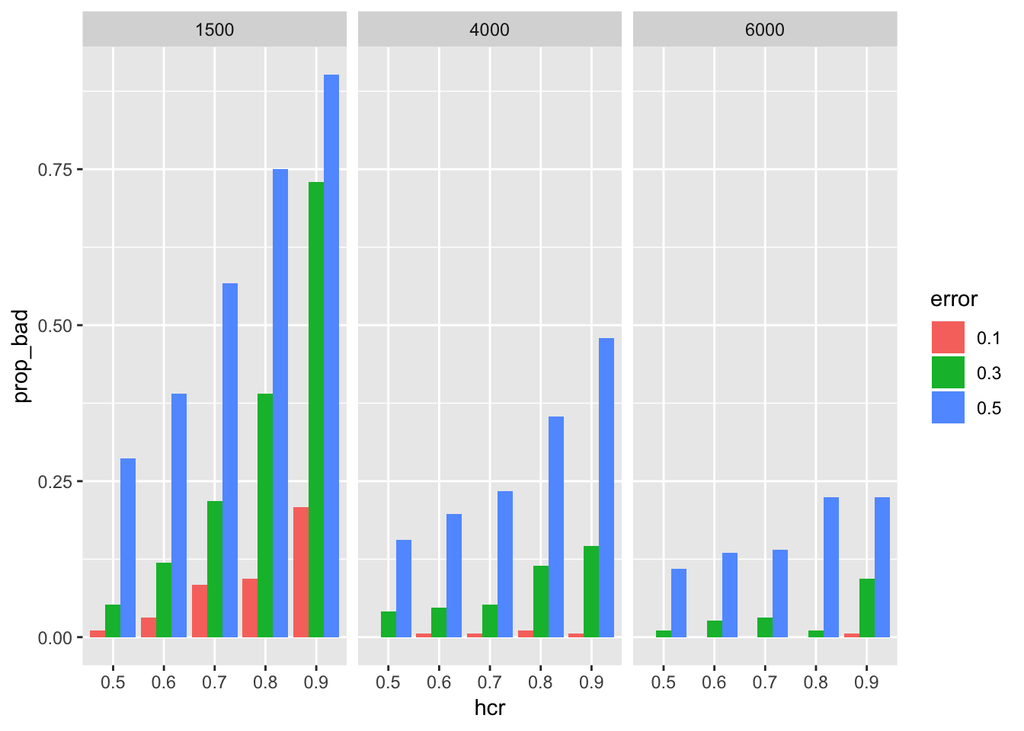

Severe climate change - facet wrap by initial biomass:

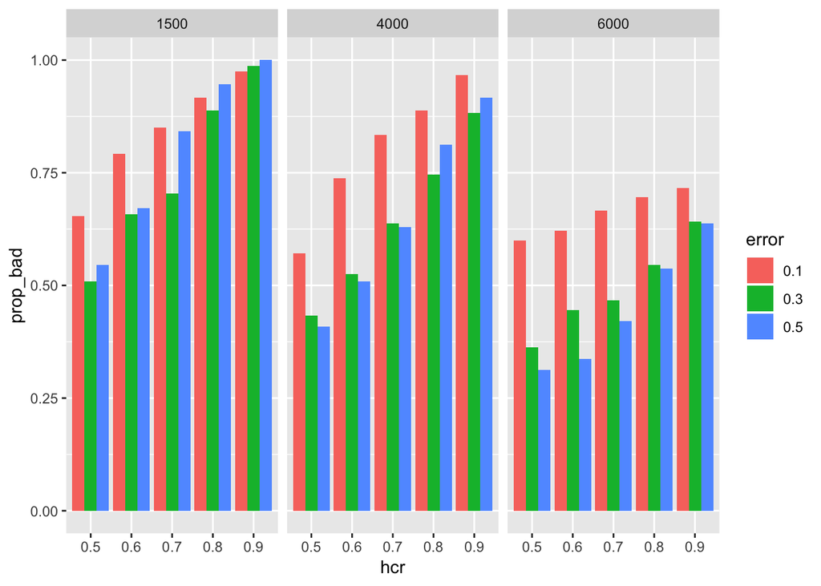

Moderate climate change - facet wrap by assessment interval:

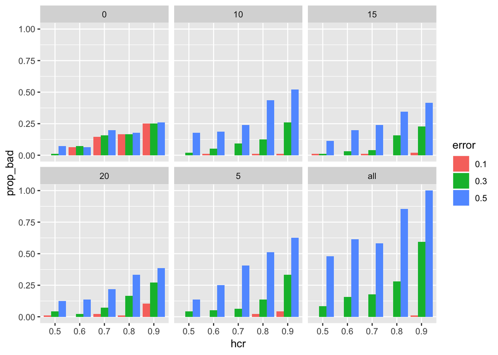

Severe climate change - facet wrap by assessment interval:

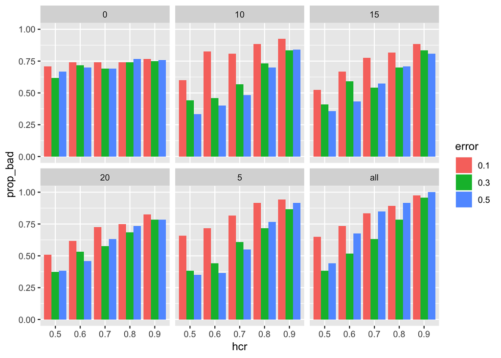

## HCRs + Assess

Harvest Control Rules & Assessment Intervals

Graphs:

Moderate climate change - facet wrap by growth rates:

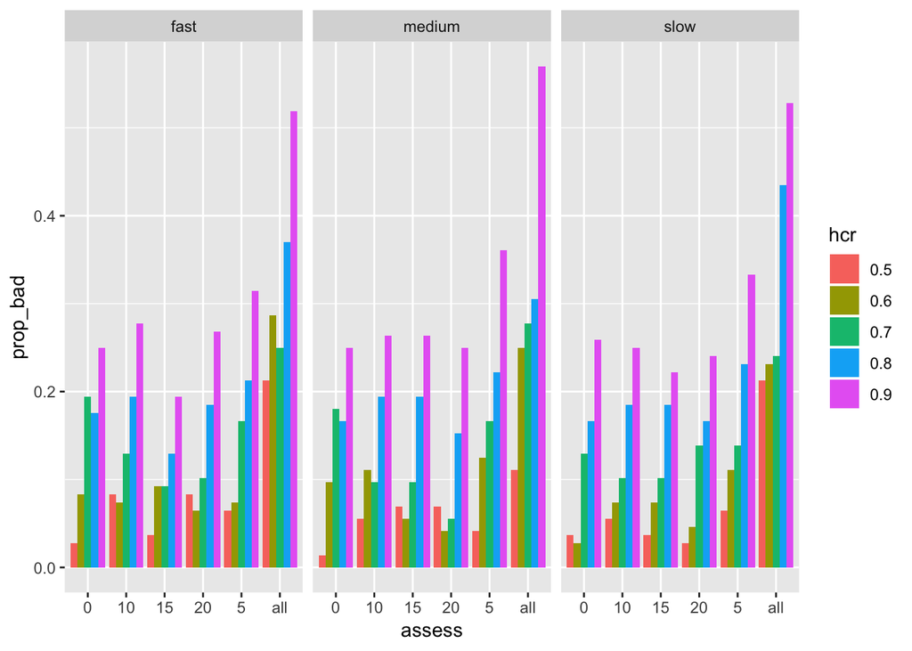

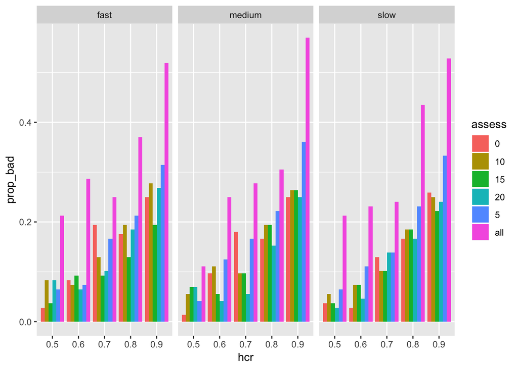

Severe climate change - facet wrap by growth rates:

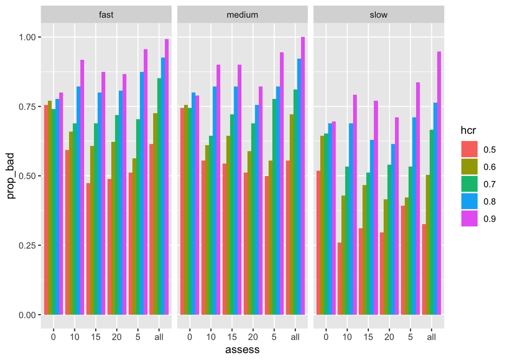

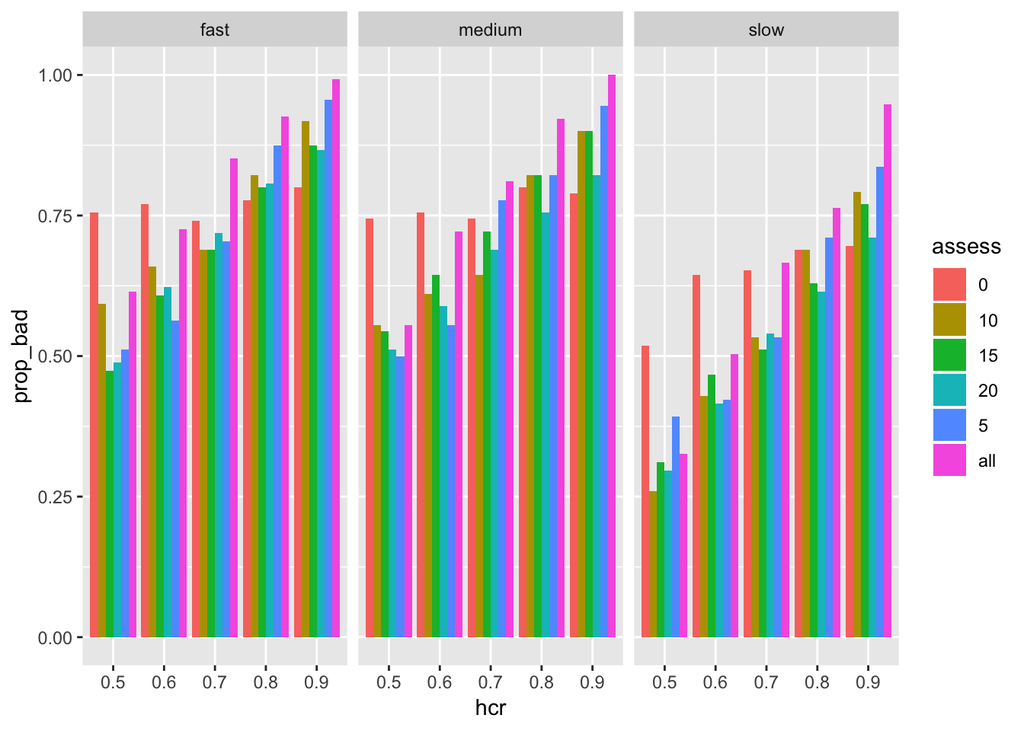

Moderate climate change - facet wrap by initial biomass:

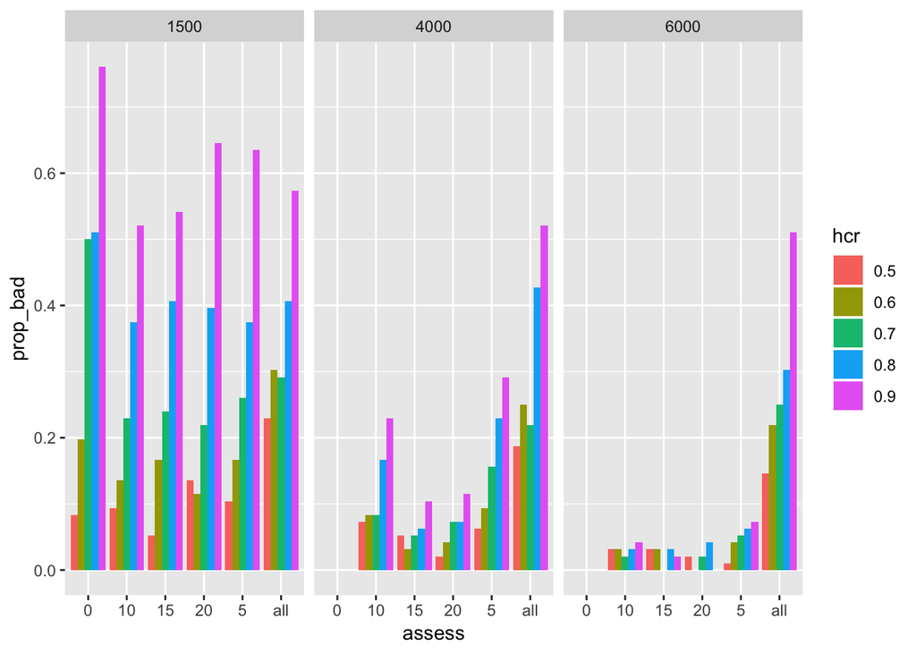

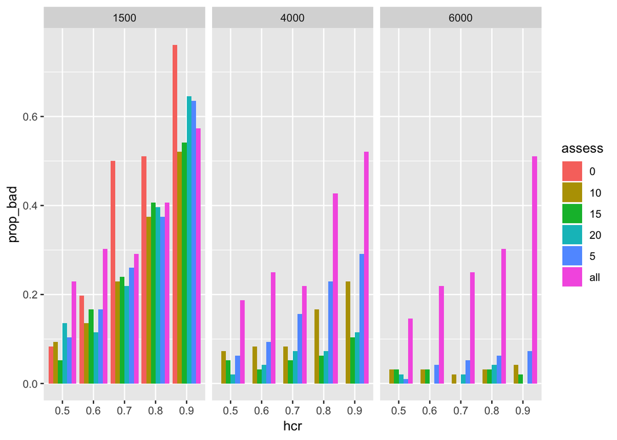

Severe climate change facet wrap by initial biomass:

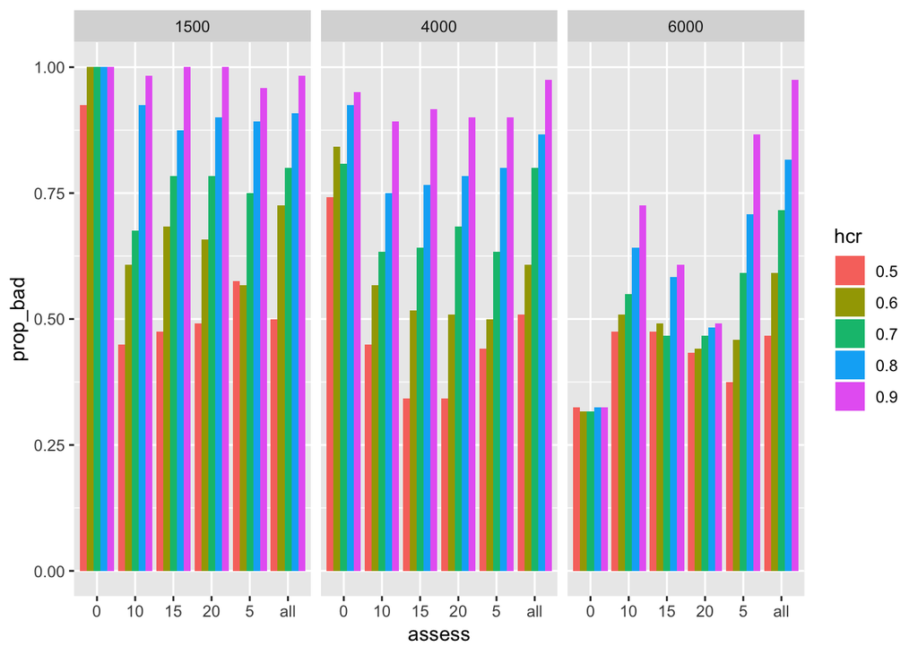

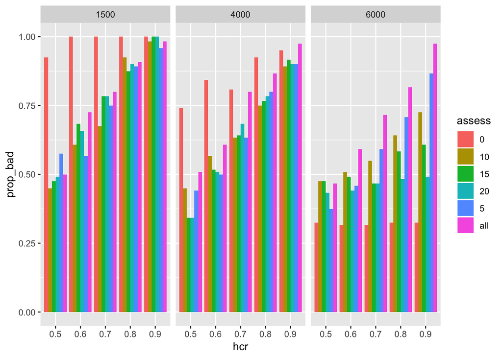

Moderate climate change - facet wrap by error:

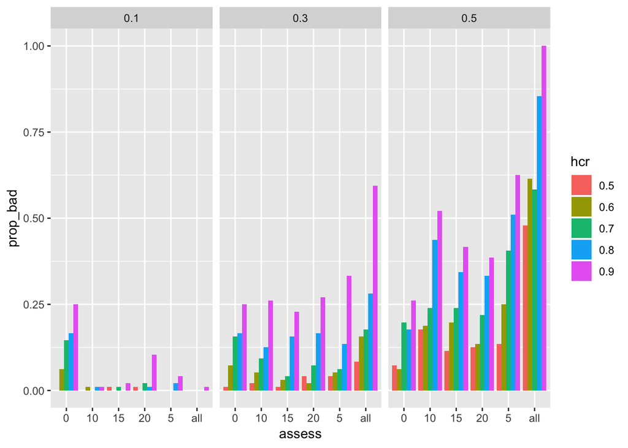

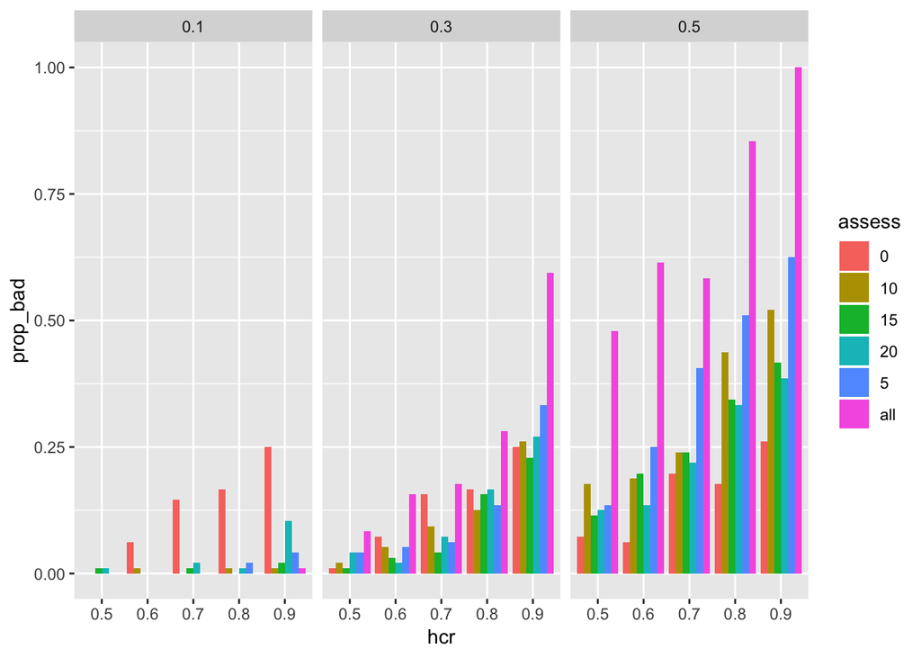

Severe climate change - facet wrap by error:

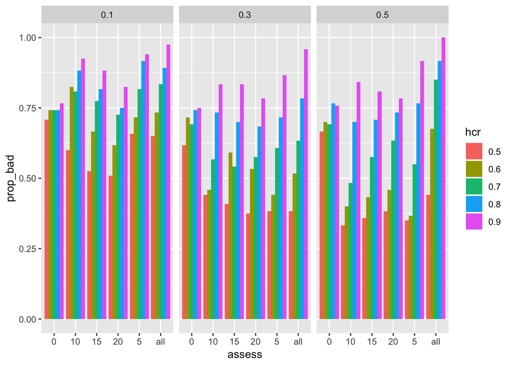

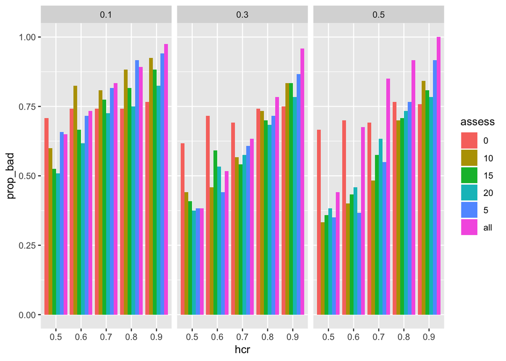

## Gracie Exploration

```r
gracie_alldata <- alldata %>%
  group_by(assess, growth, hcr, error) %>%
  filter(r_s <= 0) %>%
  filter(r_s >= -0.00767) %>%
  count(status) %>%
  spread(key = "status", value = "n") %>%
  mutate_if(is.numeric, ~replace(., is.na(.), 0)) %>%
  mutate(prop_bad = (closed + over)/(good + over + closed)) %>%
  mutate(prop_closed = (closed)/(good + over + closed)) %>%
  mutate(prop_over = (over)/(good + over))
```

```
## `mutate_if()` ignored the following grouping variables:
## Columns `assess`, `growth`, `hcr`, `error`
```

```r
gracie_alldata$assess <- as.numeric(gracie_alldata$assess)
```

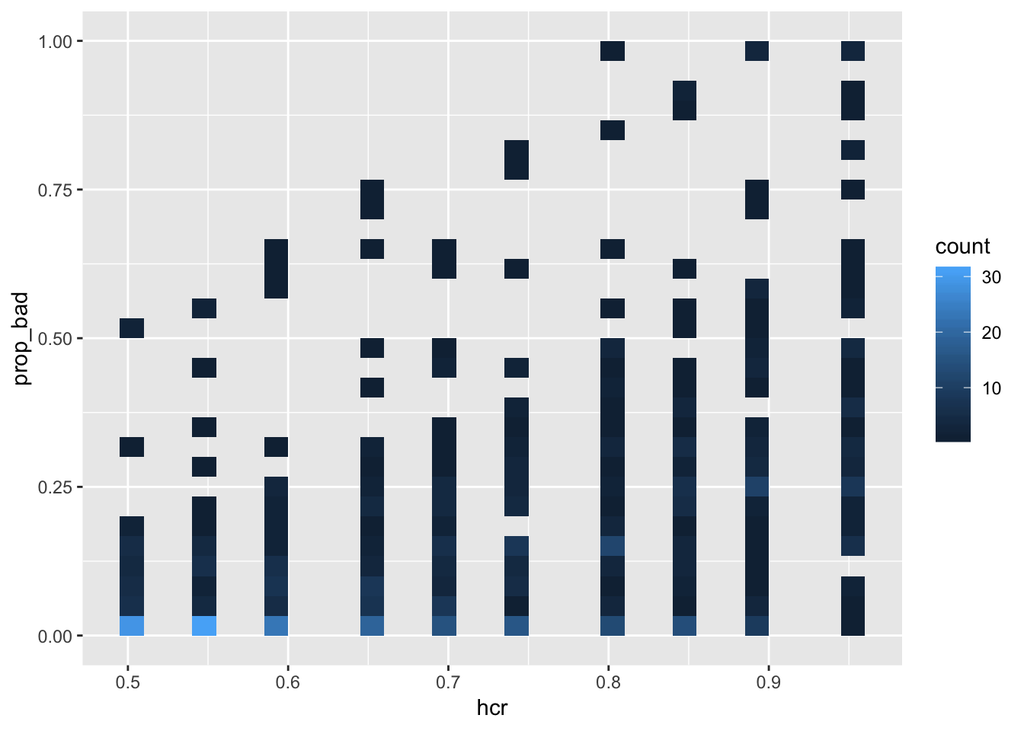

```r
gracie_alldata$hcr <- as.numeric(gracie_alldata$hcr)

bin_plot <- ggplot(gracie_alldata, aes(x=hcr, y = prop_bad))+
  geom_bin2d()
bin_plot
```

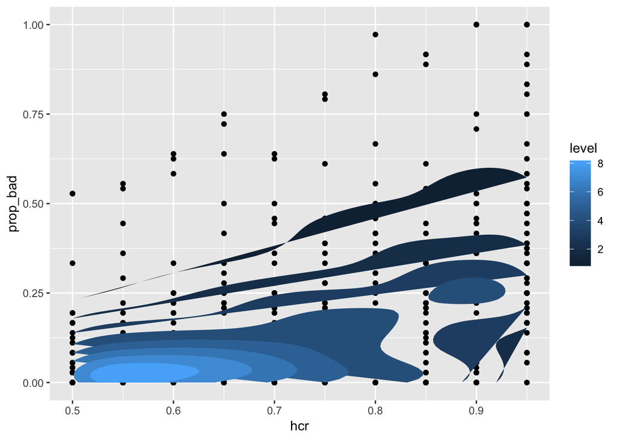

```r
#sort of cool but not that helpful
density_plot <- ggplot(gracie_alldata, aes(y = prop_bad, x = hcr)) +
  geom_point() +
  stat_density_2d(aes(fill = ..level..), geom="polygon")

density_plot
```